# Evaluation of the Real-Time Ocean Forecast System in Florida Atlantic Coastal Waters

Undergraduate research: continuation of a Marine Field Projects summer interdisciplinary cruise research project  
2007-2008

Authors

Affiliation

M.E. Splitt

Florida Institute of Technology

M.D. Grossi

Florida Institute of Technology

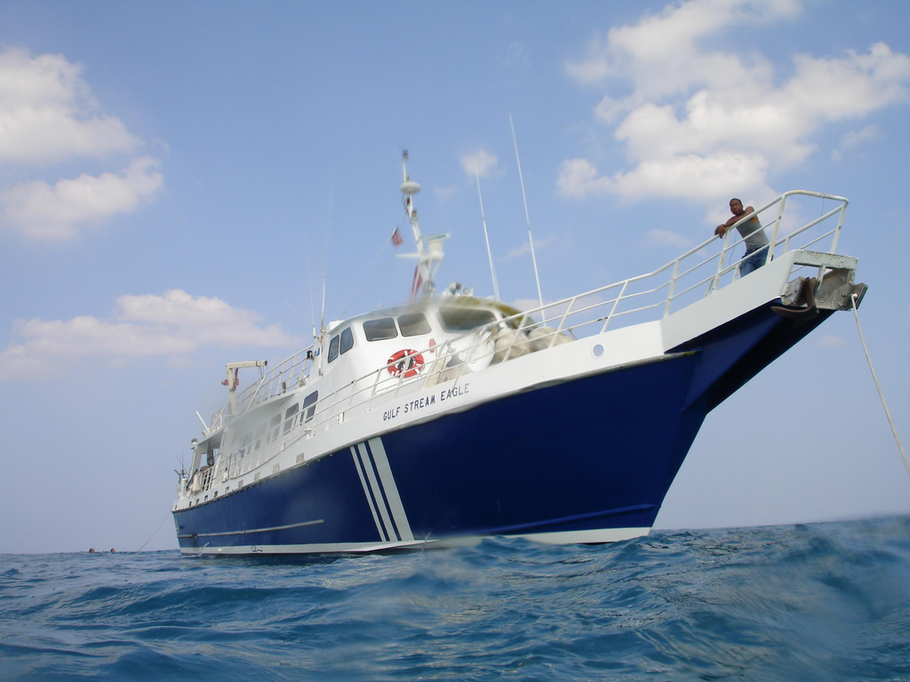

R/V *Gulf Stream Eagle*. Photo of by E. Gonzalez.

This project was the continuation of a series of summer undergraduate Marine Field Projects courses at Florida Tech. A key element of these courses involved students planning and executing a multidisciplinary 4-day/3-night research cruise aboard the R/V *Gulf Stream Eagle*, complete with a comprehensive research proposal, science objectives, and cruise plans. After the completion of the course, I worked with Mr. Michael Splitt, Assistant Professor of Meteorology, to further develop the cruise oceanography project.

The project involved using *in situ* ocean temperature, salinity, and current speed and direction data collected on a June 2007 cruise in the vacinity of the western boundary of the Gulf Stream to validate the Real-Time Ocean Forecast System (RTOFS) for the nearshore Atlantic coastal waters of southeast Florida. We compared RTOFS forecasts to these data and to buoy data from the NOAA [National Data Buoy Center](https://www.ndbc.noaa.gov/) (NDBC). Insights from these comparisons provided a basis for spatial and temporal bias evaluation of RTOFS during Fall 2007.

### Posters and Presentations

1. **Grossi, M.D.** (2007) Evaluation of the Real-Time Ocean Forecast System in Florida Atlantic Coastal Waters, Florida Institute of Technology Department of Maine & Environmental Systems Summer Symposium, Melbourne, FL. (*Both oral and poster presentation*)
2. Splitt, M.E., **M.D. Grossi** (2008) Evaluation of the Real-Time Ocean Forecast System in Florida Atlantic Coastal Waters, 2008 Ocean Sciences Meeting, March 2-7, 2008, Orlando, FL.